# 1 Introduction

We design the substructures to avoid excessive settlement and collapse of the foundation soil. Substructures transfer the load from superstructure to the soil. We assume soil as continua and calculate the stress and strain field by solving the equilibrium equations. This requires constitutive relations for the soils–stress-strain behavior under different conditions.

A mathematical model serves as the constitutive relation for the soil. We design the experiments to understand the soil and propose a mathematical model based on the experimental observations accounting for physics or statistics of the soil behavior. Experimental modeling consists of elemental experiments, mimicking the behavior of representative soil element, and small scale physical experiments, mimicking a boundary value problem. The elemental experiments help in formulating a constitutive model, whereas physical model tests validate their performance with a numerical model.

This text overviews these aspects in the following.

# 2 [Stress](https://doi.org/10.1017/CBO9780511762956)

Consider the continua subjected under different boundary conditions. We define the traction at point $\vec{x}$ on a plane with normal $\hat{n}$ as:

$$\begin{aligned}
\vec{t} &= \vec{t}\left(t, \vec{x}, \hat{n}\right)\\
&= \lim_{\delta{A}\to{0}} \dfrac{\vec{F}}{\delta{A}}
\end{aligned}$$

Where $t$ is the time, $\vec{x}$ is the coordinate of the point, and $\vec{F}$ is the force acting on an infinitesimal area $\delta{A}$. The $\lim_{\delta{A}\to{0}}$ changes to $\lim_{\delta{A}\to{\delta{A_{rve}}}}$ for soils with area of representative volume element as $\delta{A_{rve}}$.

We implicitly assume the dependence of time and avoid writing it for the sake of clarity.

[figure not shown]

Figure 1: Cauchy tetrahedron

## 2.1 Cauchy’s theorem for the existence of stress

Consider an infinitesimal tetrahedron (size $\delta$ with vertex at $\vec{x}$, fig. 1) and apply balance of linear momentum:

$$\begin{aligned}
\vec{t}\left(\vec{n}\right)\delta{A}+\sum_{i=1}^{3}\vec{t}\left(-\vec{e_{i}}\right)\delta{A_{i}}+\rho\left(\vec{b}-\vec{a}\right)\delta{V}=0
\end{aligned}$$

With infinitesimal tetrahedron, as $\delta\to{0}$,
$$\lim_{\delta\to{0}}\dfrac{\delta{V}}{\delta{A}}=0$$

Using the above:
$$\begin{aligned}
\vec{t}\left(\vec{n}\right) = -\sum_{i=1}^{3}\vec{t}\left(-\vec{e_{i}}\right)\left(\vec{n}\cdot\vec{e_{i}}\right)
\end{aligned}$$

Now, substitute $\vec{n}$ with $\vec{e_{i}}$ in the above:

$$\vec{t}\left(\vec{e_{i}}\right) = -\vec{t}\left(-\vec{e_{i}}\right)$$

Since the choice of $\vec{e_{i}}$ is arbitrary:

$$\vec{t}\left(\vec{n}\right) = -\vec{t}\left(-\vec{n}\right)$$

Which is the Newton’s law of action and reaction.

We can write the traction on plane normal to $\vec{n}$ as:

$$\vec{t}\left(\vec{n}\right)=\sum_{i=1}^{3}\vec{t}\left(\vec{e_{i}}\right)\left(\vec{n}\cdot\vec{e_{i}}\right)$$

The Cauchy stress is defined as:

$$\bar{\sigma}\left(\vec{x}\right)=\sum_{i=1}^{3}\vec{t}\left(\vec{x},\vec{e_{i}}\right)\otimes\vec{e_{i}}$$

The Cauchy stress tensor $\bar{\sigma}(\vec{x})$ (at point $\vec{x}$) maps the normal $\vec{n}$ (on a given plane through point $\vec{x}$) to traction $\vec{t}(\vec{x},\vec{n})$ (acts at point $\vec{x}$, on plane normal to $\vec{n}$):

$$\vec{t}\left(\vec{x},\vec{n}\right)=\bar{\sigma}\left(\vec{x}\right)\vec{n}$$

## 2.2 Stress components

We often deal with stress components ($\sigma_{ij}$) than the stress tensor. The first index represents the plane and second index represents the direction in which it acts. For example, $\sigma_{23}$ represents component of the stress tensor which acts on plane normal to $x_{2}$ along the direction $x_{3}$. If both indices are equal, it represents the normal stress, and different indices represent shear stress.

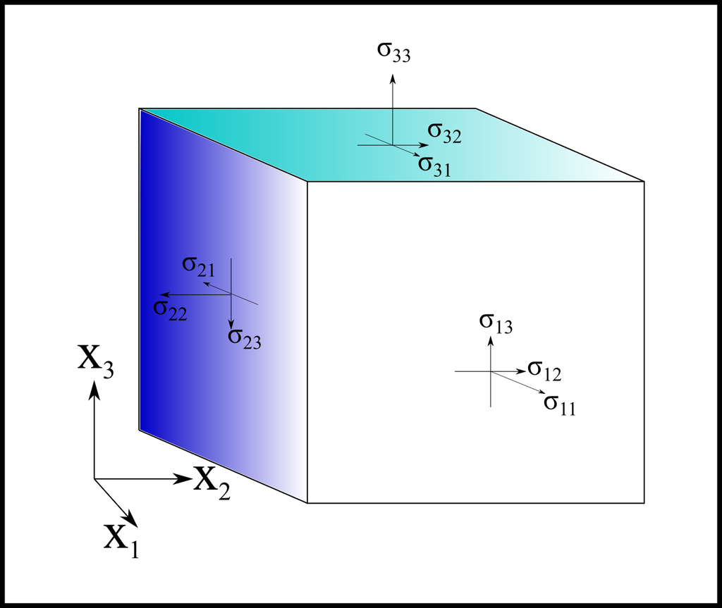

Figure 2: Stress components

## 2.3 Balance of linear momentum

Net force acting on a spatial region $\Omega_{t}$ is equal to its rate of change of linear momentum.

$$\begin{aligned}
\int_{\partial{\Omega}_{t}}\vec{t}\left(\vec{n}\right)da+\int_{\Omega_{t}}\rho\vec{b}dv=\dot{\bar{\int_{\Omega_{t}}\rho\vec{v}dv}}
\end{aligned}$$

Using the Cauchy’s theorem and Reynolds transport theorem:
$$\begin{aligned}
\int_{\partial{\Omega}_{t}}\bar{\sigma}\vec{n}da+\int_{\Omega_{t}}\rho\vec{b}dv=\int_{\Omega_{t}}\rho\dot{\vec{v}}dv
\end{aligned}$$

Using Gauss’s divergence rule:
$$\begin{aligned}
\int_{\Omega_{t}}\nabla\cdot\bar{\sigma}dv+\int_{\Omega_{t}}\rho\vec{b}dv=\int_{\Omega_{t}}\rho\dot{\vec{v}}dv\\
\int_{\Omega_{t}}\left(\nabla\cdot\bar{\sigma}+\rho\vec{b}-\rho\dot{\vec{v}}\right)dv=0
\end{aligned}$$
The region $\Omega_{t}$ is arbitrary, this leads to
$$\nabla\cdot\bar{\sigma}+\rho\vec{b}-\rho\dot{\vec{v}}=0$$

## 2.4 Balance of angular momentum

Net moment of a spatial region $\Omega_{t}$ is equal to its rate of change of angular momentum.

$$\begin{aligned}
\int_{\partial{\Omega}_{t}}\vec{x}\times\vec{t}\left(\vec{n}\right)da+\int_{\Omega_{t}}\vec{x}\times\rho\vec{b}dv=\dot{\bar{\int_{\Omega_{t}}\vec{x}\times\rho\vec{v}dv}}
\end{aligned}$$

Using the Cauchy’s theorem, balance of linear momentum and Gauss’s divergence rule:
$$\begin{aligned}
\int_{\partial{\Omega}_{t}}\vec{x}\times\left(\bar{\sigma}\vec{n}\right)da-\int_{\Omega_{t}}\vec{x}\times\left(\nabla\cdot\bar{\sigma}\right)dv=0
\end{aligned}$$

We have to apt for the indicial notation:
$$\begin{aligned}
\int_{\Omega_{t}}\sigma_{ji}\epsilon_{ijk}e_{k}=0
\end{aligned}$$

Since $\Omega_{t}$ is arbitrary:
$$\sigma_{ji}\epsilon_{ijk}=0
\qquad(1)$$

Now we have:
$$\sigma_{ij}=\sigma_{ji}$$

Hint: In eq. 1:

- Put $k=1$ and only feasible options for $i,j$ are (2,3) and (3,2).
- Put $k=2$ and only feasible options for $i,j$ are (1,3) and (3,1).
- Put $k=3$ and only feasible options for $i,j$ are (2,1) and (1,2).

## 2.5 Balance of power

Conventional external power:
$$\mathcal{W}\left(\Omega_{t}\right)\coloneq{\int_{\partial\Omega_{t}}\vec{t}\cdot\vec{v}+\int_{\Omega_{t}}\rho\vec{b}\cdot\vec{v}dv}$$

Using Cauchy’s theorem and balance of linear momentum:
$$\begin{aligned}
\int_{\partial\Omega_{t}}\vec{t}\cdot\vec{v}da&=\int_{\partial\Omega_{t}}\left(\bar{\sigma}\vec{n}\right)\cdot\vec{v}da\\
&=\int_{\Omega_{t}}\nabla\cdot\left(\bar{\sigma}^{T}\vec{v}\right)dv\\
&=\int_{\Omega_{t}}\left[\vec{v}\cdot\left(\nabla\cdot\bar{\sigma}\right)+\bar{\sigma}\colon\nabla{\vec{v}}\right]dv\\
&=\int_{\Omega_{t}}\left[\rho\vec{v}\cdot\dot{\vec{v}}-\rho\vec{v}\cdot\vec{b}+\bar{\sigma}\colon\bar{D}\right]dv\\
&=\int_{\Omega_{t}}\left[\rho\vec{v}\cdot\dot{\vec{v}}-\rho\vec{v}\cdot\vec{b}+\bar{\sigma}\colon\bar{D}\right]dv\\
\end{aligned}$$

Considering the above:
$$\begin{aligned}
\int_{\partial\Omega_{t}}\vec{t}\cdot\vec{v}+\int_{\Omega_{t}}\rho\vec{b}\cdot\vec{v}dv&=\int_{\Omega_{t}}\rho\vec{v}\cdot\dot{\vec{v}}dv+int_{\Omega_{t}}\bar{\sigma}\colon\bar{D}dv\\
&=\dot{\bar{\int_{\Omega_{t}}\dfrac{1}{2}\rho\lvert\vec{v}\rvert^{2}dv}}+\int_{\Omega_{t}}\bar{\sigma}\colon\bar{D}dv
\end{aligned}$$

We have:
$$\texttt{External power} = \texttt{Kinetic energy} + \texttt{Internal power}$$

The external power is expended on the internal power and the change in kinetic energy.

## 2.6 The first law of thermodynamics

The external power expended on $\Omega_{t}$ and net heat flow into $\Omega_{t}$ results in increase of net internal energy and kinetic energy.

$$\begin{aligned}
\dot{\bar{\mathcal{E}\left(\Omega_{t}\right)+\mathcal{K}\left(\Omega_{t}\right)}}
=\mathcal{W}\left(\Omega_{t}\right)+\mathcal{Q}\left(\Omega_{t}\right)
\end{aligned}$$

We can write net internal energy and net heat flow as:
$$\begin{aligned}
\mathcal{E}\left(\Omega_{t}\right)&=\int_{\Omega_{t}}\rho\epsilon{dv}\\
\mathcal{Q}\left(\Omega_{t}\right)&=-\int_{\partial\Omega_{t}}\vec{q}\cdot\vec{n}da +\int_{\Omega_{t}}qdv\\
\end{aligned}$$

Using the mechanical power balance, we can write the first law of energy as:
$$\begin{aligned}
\int_{\Omega_{t}}\left(\rho\dot{\epsilon}-\bar{\sigma}\colon\bar{D}+\nabla\cdot\vec{q}-q\right)dv=0\\
\rho\dot{\epsilon}=\bar{\sigma}\colon\bar{D}-\nabla\cdot\vec{q}+q
\end{aligned}$$

## 2.7 The second law of thermodynamics

The net entropy production in $\Omega_{t}$ is non-negative.

The rate of change of net internal-entropy $\dot{\bar{\mathcal{S}\left(\Omega_{t}\right)}}$ is sum of entropy flow $\mathcal{J}\left(\Omega_{t}\right)$ and net entropy production $\mathcal{H}\left(\Omega_{t}\right)$ in $\Omega_{t}$.

$$\begin{aligned}
\mathcal{H}\left(\Omega_{t}\right)\coloneq\dot{\bar{\mathcal{S}\left(\Omega_{t}\right)}}-\mathcal{J}\left(\Omega_{t}\right)
\end{aligned}$$

The second law of thermodynamics states:
$$\begin{aligned}
\mathcal{H}\left(\Omega_{t}\right)\geq{0}
\end{aligned}$$

We can write the net internal entropy in terms of the specific entropy $\eta$:
$$\begin{aligned}
\mathcal{S}\left(\Omega_{t}\right)=\int_{\Omega_{t}}\rho\eta{dv}
\end{aligned}$$

and entropy flow in terms of entropy flux $\vec{j}$ and entropy supply $j$:
$$\begin{aligned}
\mathcal{J}\left(\Omega_{t}\right)=-\int_{\partial\Omega_{t}}\vec{j}\cdot\vec{n}+\int_{\Omega_{t}}jdv
\end{aligned}$$

We can rewrite the second law of thermodynamics as:
$$\begin{aligned}
\dot{\bar{\int_{\Omega{t}}\rho\eta{dv}}}\geq-\int_{\partial\Omega{t}}\vec{j}\cdot\vec{n}da+\int_{\Omega_{t}}jdv\\
\end{aligned}$$

We have the following hypothesis:
$$\begin{aligned}
\vec{j}=\dfrac{\vec{q}}{\theta}\\
j=\dfrac{q}{\theta}
\end{aligned}$$
Where $\theta$ is the temperature.

Considering the above, we have ``Clausius-Duhem inequality"
$$\begin{aligned}
\dot{\bar{\int_{\Omega_{t}}\rho\eta{dv}}}\geq-\int_{\partial\Omega{t}}\dfrac{\vec{q}}{\theta}\cdot\vec{n}da+\int_{\Omega_{t}}\dfrac{q}{\theta}dv\\
\end{aligned}$$

We can rewrite the entropy production as:
$$\begin{aligned}
\mathcal{H}\left(\Omega_{t}\right)=\int_{\Omega_{t}}\left(\rho\dot{\eta}-\dfrac{q}{\theta}+\nabla\cdot\dfrac{\vec{q}}{\theta}\right)dv\\
\mathcal{H}\left(\Omega_{t}\right)=\int_{\Omega_{t}}\Gamma{dv}\\
\Gamma=\rho\dot{\eta}-\dfrac{q}{\theta}+\nabla\cdot\dfrac{\vec{q}}{\theta}\geq{0}
\end{aligned}$$

$$\begin{aligned}
\Gamma&=\rho\dot{\eta}-\dfrac{q}{\theta}+\dfrac{1}{\theta}\nabla\cdot\vec{q}-\frac{1}{\theta^{2}}\vec{q}\cdot\nabla{\theta}\\
\theta\Gamma&=\rho\theta\dot{\eta}-q+\nabla\cdot\vec{q}-\frac{1}{\theta}\vec{q}\cdot\nabla{\theta}\\
-\theta\Gamma&=q-\nabla\cdot\vec{q}-\rho\theta\dot{\eta}+\frac{1}{\theta}\vec{q}\cdot\nabla{\theta}\\
-\theta\Gamma&=\rho\dot{e}-\bar{\sigma}\colon\bar{D}-\rho\theta\dot{\eta}+\frac{1}{\theta}\vec{q}\cdot\nabla{\theta}\\
\end{aligned}$$

$$\begin{aligned}
\psi&=e-\theta\eta\\
\dot{\psi}&=\dot{e}-\dot{\theta}\eta-\theta\dot{\eta}
\end{aligned}$$

$$\begin{aligned}
-\int_{\Omega_{t}}\theta\Gamma{dv}&=\int_{\Omega_{t}}\left(\rho\dot{\psi}+\rho\eta\dot{\theta}-\bar{\sigma}\colon\bar{D}+\dfrac{1}{\theta}\vec{q}\cdot\nabla\theta\right)dv\\
\int_{\Omega_{t}}\theta\Gamma{dv}&=\left(\int_{\partial\Omega_{t}}\vec{t}\cdot\vec{v}da+\int_{\Omega_{t}}\rho\vec{b}\cdot\vec{v}dv\right)-\dot{\bar{\int_{\Omega_{t}}\rho\left(\psi+\dfrac{1}{2}\lvert\vec{v}\rvert^{2}\right)dv}}-\int_{\Omega_{t}}\left(\rho\eta\dot{\theta}+\dfrac{1}{\theta}\vec{q}\cdot\nabla\theta\right)dv
\end{aligned}$$

# 3 [Strain](https://doi.org/10.1017/CBO9780511762956)

Stresses result in deformation; fig. 3 shows an initial configuration and corresponding deformed configuration.

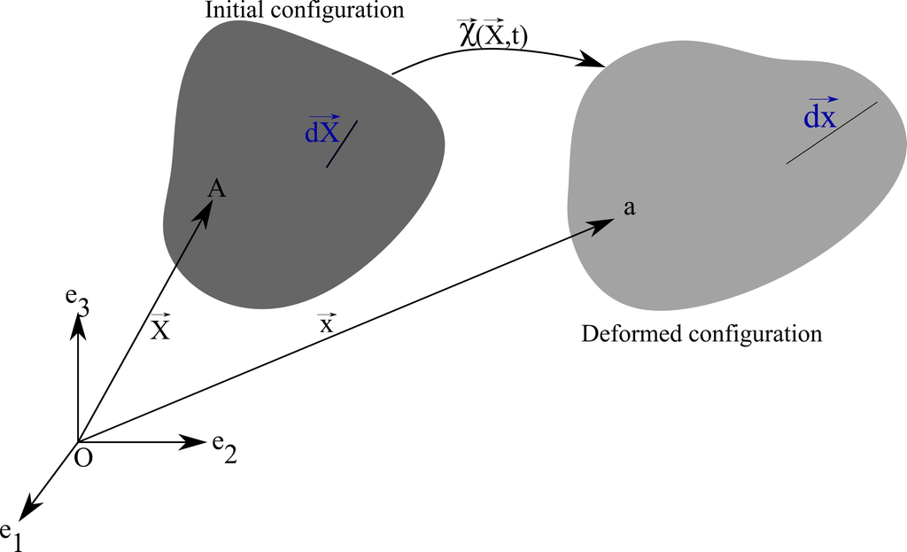

Figure 3: Deformation

fig. 3 shows the initial and deformed configuration of a spatial region $\Omega_{t}$. The mapping $\vec{x}=\vec{\chi}\left(\vec{X},t\right)$ denotes the motion of these configuration. At a fixed time, this mapping denotes the deformation. We have the following mapping for line element in the initial and deformed configuration.

$$\begin{aligned}
d\vec{x}&=\nabla_{\vec{X}}\vec{\chi}\left(\vec{X},t\right)d\vec{X}\\
&=\bar{F}\left(\vec{X},t\right)d\vec{X}
\end{aligned}$$

Mapping of the area element:
$$\begin{aligned}
\vec{n}da&=d\vec{x_{1}}\times{d\vec{x_{2}}}\\
&=\bar{F}d\vec{X_{1}}\times{\bar{F}d\vec{X_{2}}}\\
&=\mathtt{cof}\left(\bar{F}\right)\vec{N}dA
\end{aligned}$$

Mapping of the volume element:
$$\begin{aligned}
dv=\mathtt{det}\left(\bar{F}\right)dV
\end{aligned}$$

Definition of strains:
$$\begin{aligned}
d{\vec{x_{1}}}.d{\vec{x_{2}}}-d{\vec{X_{1}}}.d{\vec{X_{2}}}&=
\left(\bar{F}^{T}\bar{F}-\bar{I}\right)d{\vec{X_{1}}}.d{\vec{X_{2}}}\\
&=2\bar{E}d{\vec{X_{1}}}.d{\vec{X_{2}}}
\end{aligned}$$

Where $\bar{E}=\dfrac{1}{2}\left(\bar{F}^{T}\bar{F}-\bar{I}\right)$ is the Green-Lagrangian strain tensor.

$$\begin{aligned}
d{\vec{x_{1}}}.d{\vec{x_{2}}}-d{\vec{X_{1}}}.d{\vec{X_{2}}}&=
\left(\bar{I}-\bar{F}^{-T}\bar{F}^{-1}\right)d{\vec{x_{1}}}.d{\vec{x_{2}}}\\
&=2\bar{\hat{E}}d{\vec{x_{1}}}.d{\vec{x_{2}}}
\end{aligned}$$

Where $\bar{\hat{E}}=\dfrac{1}{2}\left(\bar{I}-\bar{F}^{-T}\bar{F}^{-1}\right)$ is the Eulerian-Almansi strain tensor.

The displacement field $u\left(\vec{X}\right)$ is:
$$\begin{aligned}
\vec{u}\left(\vec{X}\right)&=\vec{x}-\vec{X}\\
\nabla_{\vec{X}}\vec{u}&=\bar{F}-\bar{I}\\
\nabla_{\vec{x}}\vec{u}&=\bar{I}-\bar{F}^{-1}\\
\bar{F}&=\nabla_{\vec{X}}\vec{u}+\bar{I}\\
\bar{F}^{-1}&=\bar{I}-\nabla_{\vec{x}}\vec{u}
\end{aligned}$$

Now, the strain tensors can be written as:
$$\begin{aligned}
\bar{E}&=\dfrac{1}{2}\left(\nabla_{\vec{X}}\vec{u}+\left(\nabla_{\vec{X}}\vec{u}\right)^{T}+\left(\nabla_{\vec{X}}\vec{u}\right)^{T}\nabla_{\vec{X}}\vec{u}\right)\\
\bar{\hat{E}}&=\dfrac{1}{2}\left(\nabla_{\vec{x}}\vec{u}+\left(\nabla_{\vec{x}}\vec{u}\right)^{T}-\left(\nabla_{\vec{x}}\vec{u}\right)^{T}\nabla_{\vec{x}}\vec{u}\right)
\end{aligned}$$

# 4 Coordinate transformation

The tensor is invariant to coordinate transform, however, the components changes with the basis. Tensor components transform with the following rule:

$$\begin{aligned}
\tilde{\sigma}_{kl} &= Q_{ik}\sigma_{ij}Q_{jl}
\end{aligned}$$

We derive this in the following:
$$\begin{aligned}
\bar{\sigma} &= \sigma_{ij}e_{i}\otimes{e_{j}} \\
\end{aligned}$$

Coordinate transformation rule
$$\begin{aligned}
\tilde{e}_{i} &= Q_{ik}e_{k} \\
\end{aligned}$$

Stress tensor remains invariant under coordinate transformation
$$\begin{aligned}
\bar{\sigma} &= \sigma_{ij}Q_{ik}Q_{jl}e_{k}\otimes{e_{l}}\\
&= \tilde{\sigma}_{kl}e_{k}\otimes{e_{l}}\\
\end{aligned}$$

By comparing the components, we have:
$$\begin{aligned}
\tilde{\sigma}_{kl} &= Q_{ik}\sigma_{ij}Q_{jl}
\end{aligned}$$

## 4.1 Three dimensional stress tensor

For a plane passing through the point with stress tensor as $\sigma_{ij}$,

We evaluate the traction as:
$$\vec{t}=\bar{\sigma}\vec{n}$$

Correspondingly, the normal and shear stress are:
$$\begin{aligned}
\sigma_{n}&=\vec{n}\cdot\vec{t}\\
&=\vec{n}\cdot\bar{\sigma}\vec{n}\\
&=\sigma_{1}n_{1}^{2}+\sigma_{2}n_{2}^{2}+\sigma_{3}n_{3}^{2}\\
\tau_{n}&=\sqrt{\lvert\vec{t}\rvert^{2}-\sigma_{n}^{2}}\\
\sigma_{n}^{2}+\tau_{n}^{2}&=\sigma_{1}^{2}n_{1}^{2}+\sigma_{2}^{2}n_{2}^{2}+\sigma_{3}^{2}n_{3}^{2}\\
\end{aligned}$$

With the above equation for $\tau_{n}$, we have two signs.

We also have
$$n_{1}^{2}+n_{2}^{2}+n_{3}^{3}=1$$

We have the set of linear equations:
$$\begin{aligned}
\begin{bmatrix}
1 & 1 & 1 \\
\sigma_{1} & \sigma_{2} & \sigma_{3}\\
\sigma_{1}^{2} & \sigma_{2}^{2} & \sigma_{3}^{2}
\end{bmatrix}
\begin{Bmatrix}
n_{1}^{2}\\
n_{2}^{2}\\
n_{3}^{2}
\end{Bmatrix}
&=
\begin{Bmatrix}
1\\
\sigma_{n}\\
\sigma_{n}^{2}+\tau_{n}^{2}
\end{Bmatrix}
\end{aligned}$$

Assuming $\sigma_{1}\neq\sigma_{2}\neq\sigma_{3}$:

$$\begin{aligned}
\begin{Bmatrix}
n_{1}^{2}\\
n_{2}^{2}\\
n_{3}^{2}
\end{Bmatrix}
&=
\begin{bmatrix}
\frac{\sigma_{2}\sigma_{3}}{\left(\sigma_{1}-\sigma_{2}\right)\left(\sigma_{1}-\sigma_{3}\right)}
& -\frac{\sigma_{2}+\sigma{3}}{\left(\sigma_{1}-\sigma_{2}\right)\left(\sigma_{1}-\sigma_{3}\right)}
& \frac{1}{\left(\sigma_{1}-\sigma_{2}\right)\left(\sigma_{1}-\sigma_{3}\right)}\\
\frac{\sigma_{3}\sigma_{1}}{\left(\sigma_{2}-\sigma_{3}\right)\left(\sigma_{2}-\sigma_{1}\right)}
& -\frac{\sigma_{3}+\sigma{1}}{\left(\sigma_{2}-\sigma_{3}\right)\left(\sigma_{2}-\sigma_{1}\right)}
& \frac{1}{\left(\sigma_{2}-\sigma_{3}\right)\left(\sigma_{2}-\sigma_{1}\right)}\\
\frac{\sigma_{1}\sigma_{2}}{\left(\sigma_{3}-\sigma_{1}\right)\left(\sigma_{3}-\sigma_{2}\right)}
& -\frac{\sigma_{1}+\sigma{2}}{\left(\sigma_{3}-\sigma_{1}\right)\left(\sigma_{3}-\sigma_{2}\right)}
& \frac{1}{\left(\sigma_{3}-\sigma_{1}\right)\left(\sigma_{3}-\sigma_{2}\right)}\\
\end{bmatrix}
\begin{Bmatrix}
1\\
\sigma_{n}\\
\sigma_{n}^{2}+\tau_{n}^{2}
\end{Bmatrix}
\end{aligned}$$

With $n_{1}^{2}\geq{0},n_{2}^{2}\geq{0},n_{3}^{2}\geq{0}$, and assuming $\sigma_{1}\geq\sigma_{2}\geq\sigma_{3}$:

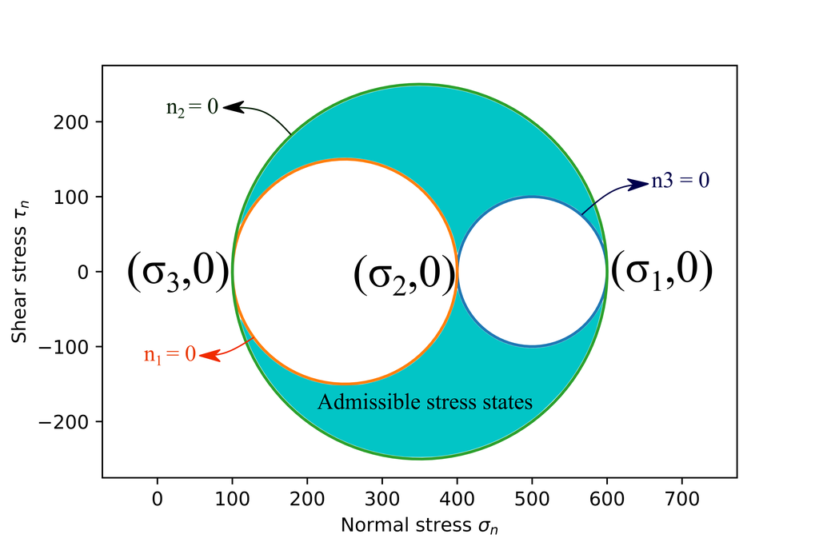

Figure 4: Three dimensional Mohr circle

fig. 4 shows the admissible stress states.

## 4.2 Two-dimensional stress tensor

fig. 5 shows the original coordinate system $x_{1}-x_{2}$ and transformed coordinate system $\tilde{x}_{1}-\tilde{x}_{2}$. The rotation matrix is given by:

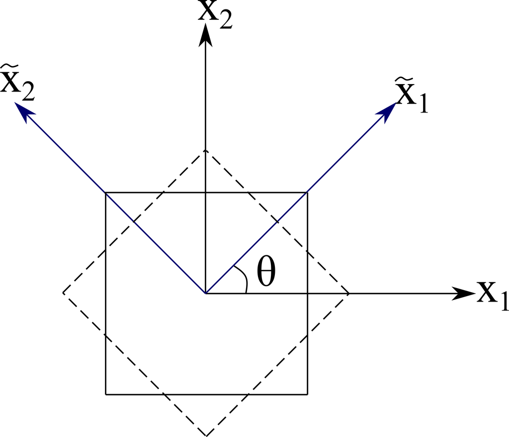

Figure 5: Coordinate transformation in two-dimension

$$\begin{aligned}
Q_{ij} &= \tilde{e}_{i}\cdot{e}_{j}\\
\left[Q_{ij}\right]
&=
\begin{bmatrix}
\cos{\theta} & \sin{\theta}\\
-\sin{\theta} & \cos{\theta}
\end{bmatrix}
\end{aligned}$$

The stress components in the transformed coordinate system:
$$\begin{aligned}
\tilde{\sigma}_{ij} &= Q_{ki}\sigma_{kl}Q_{lj}\\
\tilde{\sigma}_{11} &=
\dfrac{\sigma_{11}+\sigma_{22}}{2}+\dfrac{\sigma_{11}-\sigma_{22}}{2}\cos{2\theta}+\sigma_{12}\sin{2\theta}\\
\tilde{\sigma}_{12} &=
\sigma_{12}\cos{2\theta}+\dfrac{\sigma_{22}-\sigma_{11}}{2}\sin{2\theta}
\end{aligned}$$

If we desire to estimate the normal and shear stress on the plane normal to $\tilde{x}_{1}$:
$$\begin{aligned}
\sigma_{n}-\dfrac{\sigma_{11}+\sigma_{22}}{2} &=
\dfrac{\sigma_{11}-\sigma_{22}}{2}\cos{2\theta}+\sigma_{12}\sin{2\theta}\\
&= R\sin\left(2\theta+\phi\right)\\
\tau_{n} &=
\sigma_{12}\cos{2\theta}-\dfrac{\sigma_{11}-\sigma_{22}}{2}\sin{2\theta}\\
&= R\cos\left(2\theta+\phi\right)\\
R &= \sqrt{\sigma_{12}^{2}+\left(\dfrac{\sigma_{11}-\sigma_{22}}{2}\right)^{2}}\\
\tan\phi &= \dfrac{\sigma_{11}-\sigma_{22}}{2\sigma_{12}}
\end{aligned}$$

The locus of normal and shear stress is a circle, called Mohr circle.

# 5 [Mohr Circle](https://my.mech.utah.edu/~brannon/public/Mohrs_Circle.pdf)

The Mohr circle is very useful in quickly extracting the tensor values on different planes or in extracting the planes corresponding to different tensor values. The method of poles in particularly interesting in Mohr circles. It only works with the right sign conventions:

- Compression positive and counterclockwise shear positive
- Tension positive and clockwise shear positive

In the following, we see how pole appears with compression positive and counterclockwise shear positive.

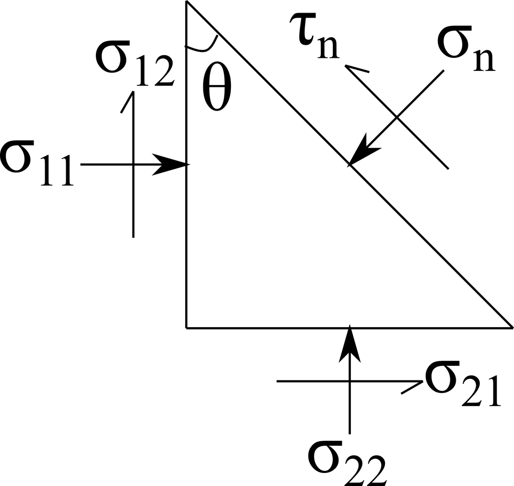

Figure 6: Stress-state

For an element with the stress state given in the fig. 6, we have normal stress and shear sterss on the plane normal to $\vec{n}=\cos{\theta}\vec{e}_{1}+\sin{\theta}\vec{e}_{2}$ as:

$$\begin{aligned}
\sigma_{n} &= \dfrac{\sigma_{11}+\sigma_{22}}{2}+\dfrac{\sigma_{11}-\sigma_{22}}{2}\cos{2\theta}+\sigma_{12}\sin{2\theta}\\
&= \dfrac{\sigma_{11}+\sigma_{22}}{2}+R\sin\left(2\theta+\phi\right)\\
\tau_{n} &= \dfrac{\sigma_{11}-\sigma_{22}}{2}\sin{2\theta}-\sigma_{12}\cos{2\theta}\\
&= -R\cos\left(2\theta+\phi\right)\\
R &= \sqrt{\left(\dfrac{\sigma_{11}-\sigma_{22}}{2}\right)^{2}+\sigma_{12}^{2}}\\
\tan{\phi} &= \dfrac{\sigma_{11}-\sigma_{22}}{2\sigma_{12}}\\
\end{aligned}$$

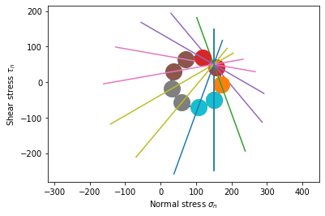

Pole

```python
# import the libraries

import numpy as np
from matplotlib import pyplot as plt

# stress state at the point
s11 = 150
s12 = 50
s22 = 50

# radius and center of the Mohr circle
R = np.sqrt(((s11-s22)/2)**2+s12**2)
center = (s11+s22)/2
phi = np.arctan((s11-s22)/(2*s12)) # twice the inclination of principal plane

# number of points on the Mohr circle and lenght of the plane
num_points = 100
length_plane = 400

# stress states on the Mohr circle for different theta values
snfn = lambda t: center + R * np.sin(2*t+phi)
tnfn = lambda t: -1 * R * np.cos(2*t+phi)
theta = np.linspace(0, 2*np.pi, num=num_points)
sn = snfn(theta)
tn = tnfn(theta)

'''
plot the Mohr circle and the planes on which stresses, at the point in the
Mohr circle, acts.
From [@fig:StressState] direction cosines of the plane are
[cos(270+theta), sin(270+theta)] --> [sin(theta), -cos(theta)]
The line that represents plane on the Mohr circle has start point
$\left(x-\frac{l}{2}\sin{\theta},y+\frac{l}{2}\cos{\theta}\right)$ and end
point $\left(x+\frac{l}{2}\sin{\theta},y-\frac{l}{2}\cos{\theta}\right)$. The
point $\left(x,y\right)$ is the point on the Mohr circle.
'''
plt.figure()
plt.plot(sn, tn)
for i in np.linspace(0, 2*np.pi, num =10):
    # point on the Mohr circle
    plt.plot(snfn(i), tnfn(i), 'o', MarkerSize=20)
    # start and end points
    start = [snfn(i)-length_plane/2*np.sin(i),tnfn(i)+length_plane/2*np.cos(i)]
    end = [snfn(i)+length_plane/2*np.sin(i),tnfn(i)-length_plane/2*np.cos(i)]
    point_x = [start[0], end[0]]
    point_y = [start[1], end[1]]
    plt.plot(point_x, point_y, '-')
plt.axis('equal')
plt.xlabel(r'Normal stress $\sigma_{n}$')
plt.ylabel(r'Shear stress $\tau_{n}$')
```

## 5.1 Mohr circle of strain

fig. 7 shows the strain state in an element. We consider contraction and counterclockwise shear as positive. In the fig. 7, strain state is the following:

$$\begin{aligned}
d\epsilon_{11} &= \dfrac{\delta{l}_{11}}{l_{1}}\\
d\epsilon_{12} &= \dfrac{d\gamma_{12}}{2}\\
&= \dfrac{1}{2}\left(\dfrac{\delta{l}_{12}}{l_{1}}+\dfrac{\delta{l}_{21}}{l_{2}}\right)\\
d\epsilon_{21} &= \dfrac{d\gamma_{21}}{2}\\
&= -\dfrac{1}{2}\left(\dfrac{\delta{l}_{12}}{l_{1}}+\dfrac{\delta{l}_{21}}{l_{2}}\right)\\
d\epsilon_{22} &= -\dfrac{\delta{l}_{22}}{l_{2}}
\end{aligned}$$

Note that the sign convention here is according the Mohr circle and the above does not imple the strain tensor is assymetric. The engineering shear strain $d\gamma_{12}$ is the change in angle between two perpendicular line elements in the initial configuration.

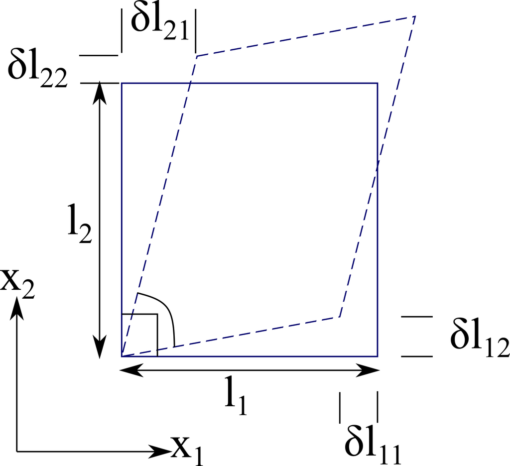

Figure 7: Strain state

fig. 8 shows the Mohr circle corrsponding to this strain state. The strain components $d\epsilon_{11}, d\epsilon_{12}$ act on the verticle plane; we obtain the pole by drawing the verticle line at $d\epsilon_{11}, d\epsilon_{12}$ which intersects the Mohr circle at the pole. The line joining the pole and zero normal strain points correspond to plane of zero extension and line perpendicular to that is the zero extension line.

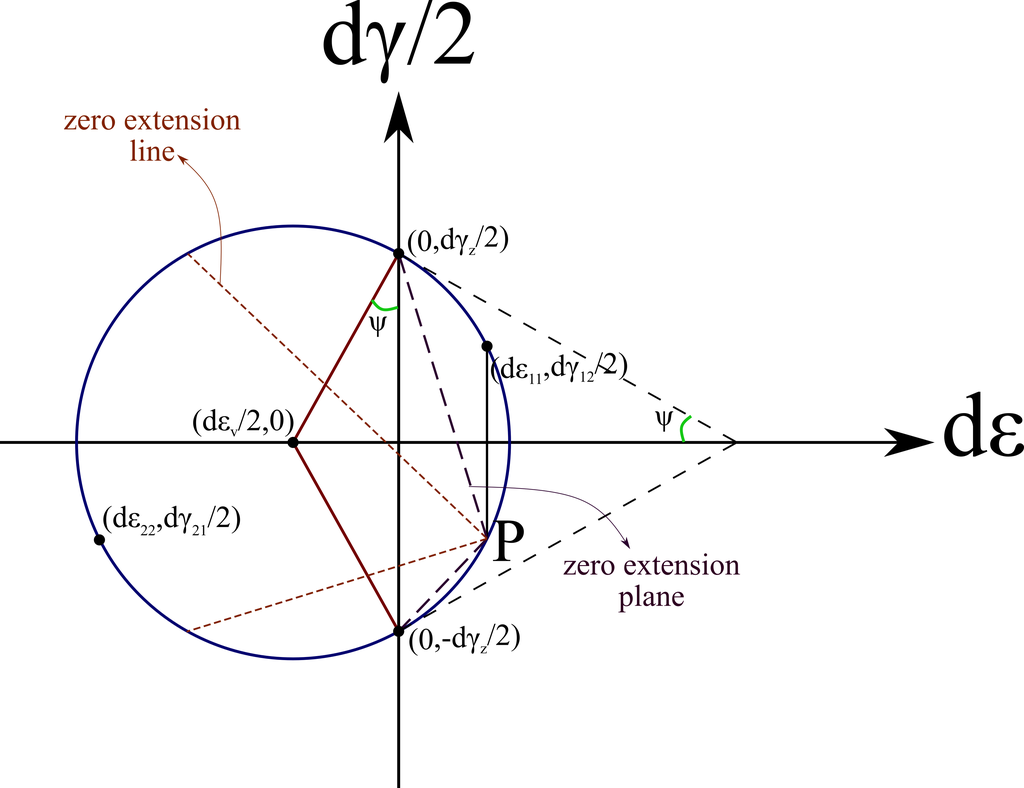

Figure 8: Strain Mohr Circle

## 5.2 [Dilatancy](https://doi.org/10.1080/14786448508627791)

Granular media changes its volume upon distortion; this property is known as dilatancy.

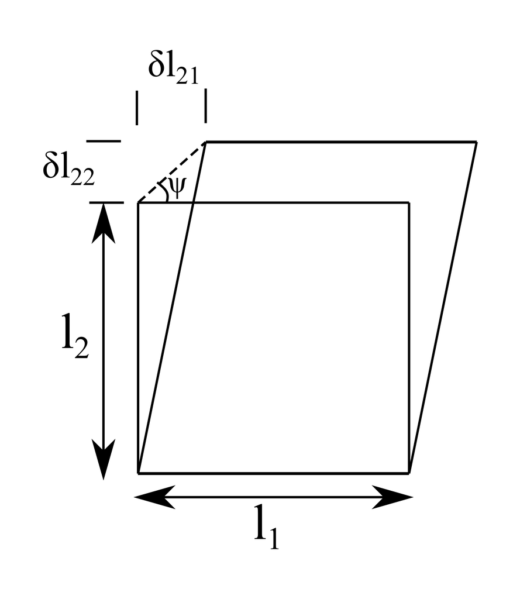

Figure 9: Dilatancy

fig. 9 shows an element under distortion along $x_{1}$; there is no contraction or dilation along this direction. The line of zero extension lies along $x_{1}$. Angle of dilatancy ($\psi$) is defined as

$$\begin{aligned}
\tan\psi &= \dfrac{\delta{l}_{22}}{\delta{l}_{21}}\\
&= -\dfrac{d\epsilon_{22}}{d\gamma_{z}}\\
&= -\dfrac{d\epsilon_{v}}{d\gamma_{z}}
\end{aligned}$$

Slip surfaces in soil mass have the shape of logarithmic spiral. When a contiguous elements reach the failure in soil, a slip surface forms. The soil around the slip surface behaves as a rigid block such that distortion occurs within the slip surface. The tangents to slip surfaces are lines of zero extension. From the fig. 10:

$$\begin{aligned}
\tan{\psi} &= \dfrac{rd\theta}{dr}\\
\log{r}\rvert_{r=r_{0}}^{r} &=
\theta\tan{\psi}\rvert]_{\theta=0}^{\theta}\\
r &= r_{0}\exp\left(\theta\tan\psi\right)
\end{aligned}$$

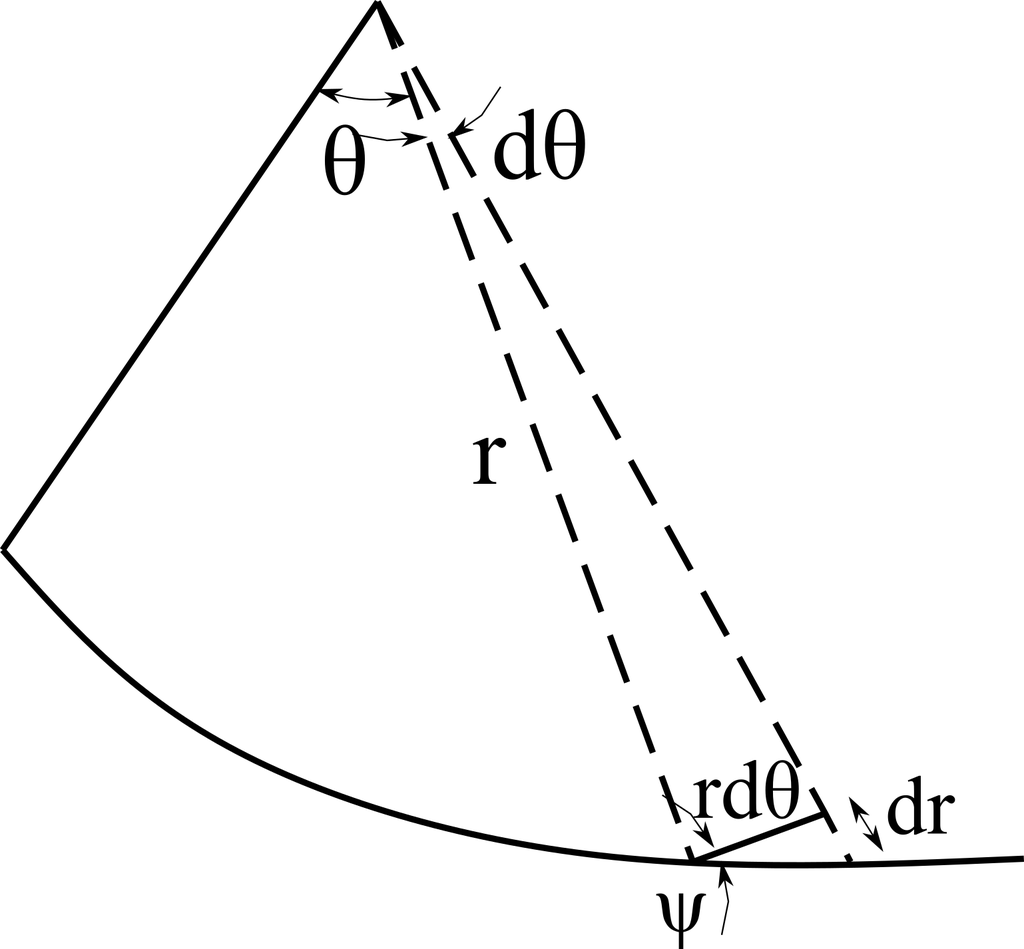

Figure 10: Slip surface

# 6 Failure criteria

## 6.1 Mohr-Coulomb failure criteria

$$\begin{aligned}
\tau &= c+\sigma\tan{\phi}\\
t &= c\cos{\phi}+s\sin{\phi}\\
\sigma_{1} &= \sigma_{3}N_{\phi}+2c\sqrt{N{\phi}}
\end{aligned}$$

Where $\sigma_{1}$ and $\sigma_{3}$ are major and minor principal stresses, and $s=\frac{\sigma_{1}+\sigma_{3}}{2}$, $t=\frac{\sigma_{1}-\sigma_{3}}{2}$ are the peak of the Mohr-Circle.

## 6.2 Hoek-Brown failure criteria

$$\begin{aligned}
\sigma_{1} = \sigma_{3}+q_{u}\sqrt{m\frac{\sigma_{3}}{q_{u}}+s}
\end{aligned}$$

# 7 Rotation of stress tensor

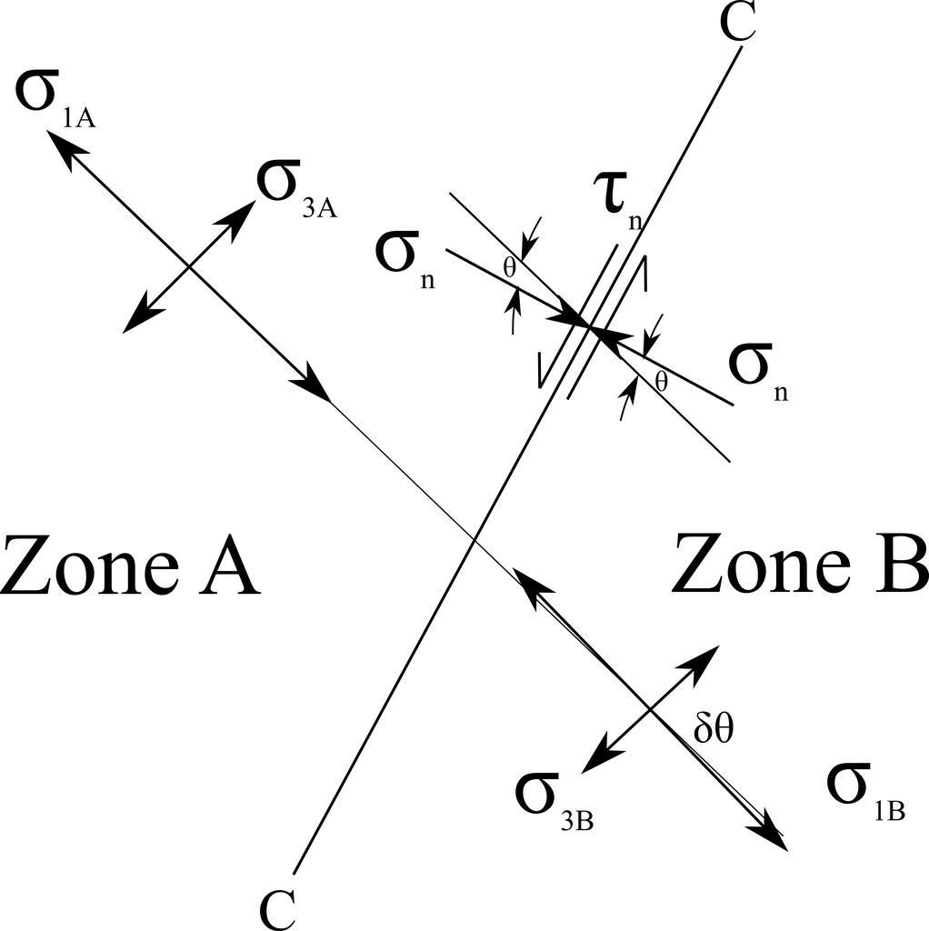

Figure 11: Stress rotation

For zone A, we can write the following –

$$\begin{aligned}
\sigma_{n} &= \dfrac{\sigma_{1A}+\sigma_{3A}}{2}
+ \dfrac{\sigma_{1A}-\sigma_{3A}}{2}\cos{2\theta}\\
\tau_{n} &= \dfrac{\sigma_{1A}-\sigma_{3A}}{2}\sin{2\theta}
\end{aligned}$$

For zone B, we can write the following –

$$\begin{aligned}
\sigma_{n} &= \dfrac{\sigma_{1B}+\sigma_{3B}}{2}
+ \dfrac{\sigma_{1B}-\sigma_{3B}}{2}\cos\left(2\theta+2\delta\theta\right)\\
\tau_{n} &=
\dfrac{\sigma_{1B}-\sigma_{3B}}{2}\sin\left(2\theta+2\delta\theta\right)
\end{aligned}$$

In general, the shear and normal stress at the discontinuity can be written as –

$$\begin{aligned}
\sigma_{n} &= s + t\cos{2\theta}\\
\tau_{n} &= t\sin{2\theta}
\end{aligned}$$

At the zone of discontinuity, we also have –

$$\begin{aligned}
d\sigma_{n} &= 0 \\
d\tau_{n} &= 0 \\
\end{aligned}$$

This implies –

$$\begin{aligned}
ds + dt\cos{2\theta} - 2t\sin{2\theta}\delta\theta &=0 \\
dt\sin{2\theta} + 2t\cos{2\theta}\delta\theta &= 0\\
\end{aligned}$$

## 7.1 Cohesive soils

For the cohesive soil, the Mohr-Coulomb failure criteria is given as:

$$\begin{aligned}
\tau = c_{u}
\end{aligned}$$

Where $c_{u}$ is the undrained cohesive strength.

The radius of Mohr circle doesn’t change at failure –

$$\begin{aligned}
ds = 2c_{u}\delta\theta
\end{aligned}$$

Note $2\theta=\frac{\pi}{2}$.

## 7.2 Cohesion-less soils

For a cohesion-less soil, the Mohr-Coulomb failure criteria is given as:

$$\begin{aligned}
\tau &= \sigma\tan{\phi} \\
t &= s\sin{\phi}
\end{aligned}$$

Also $2\theta=\frac{\pi}{2}+\phi$.

$$\begin{aligned}
ds - dt\sin{\phi} - 2t\cos{\phi}\delta\theta &=0 \\
dt\cos{\phi} - 2t\sin{\phi}\delta\theta &= 0\\
\end{aligned}$$

From the above, we have –

$$\begin{aligned}
ds &= 2t\delta\theta\left(\cos\phi+\frac{\sin^{2}\phi}{\cos{\phi}}\right) \\
ds &= 2s\left(\tan{\phi}\right)\delta\theta
\end{aligned}$$

# 8 Readings

A good knowledge of continuum mechanics helps in understanding soil mechanics and soil plasticity.

1. Gurtin, M.E., Fried, E. and Anand, L., 2010. The mechanics and thermodynamics of continua. Cambridge University Press.
2. http://solidmechanics.org/contents.php [highly recommended]
3. Jog, C.S., 2015. Continuum mechanics (Vol. 1). Cambridge University Press. [My teacher’s book.]